# Análisis de Sentimiento de Reviews para un Hotel

## MEA519-01

### Autor: Pablo Perez, Wittenberg Corniel

### ID: 1064601, 1107854

El análisis de sentimiento es parte de las técnicas de Procesamiento del Lenguaje Natural (NLP) que consiste en extraer las emociones relacionadas con algunos textos sin procesar. Esto suele utilizarse en publicaciones en redes sociales y reseñas de clientes para comprender automáticamente si algunos usuarios son positivos o negativos y por qué. El objetivo de este estudio es mostrar cómo se puede realizar el análisis de sentimiento utilizando Python. Aquí están algunas de las principales bibliotecas que utilizaremos:

*NLTK*: el módulo de Python más famoso para técnicas de NLP.

*TextBlob*: es una biblioteca de procesamiento de lenguaje natural (NLP) en Python que .simplifica tareas de análisis de texto.

*Scikit-learn*: la biblioteca de aprendizaje automático más utilizada en Python.

*Stopwords*: es una colección de palabras comunes en un idioma específico que suelen ser eliminadas durante el procesamiento de texto en tareas de procesamiento de lenguaje natural (NLP) debido a que no aportan un significado informativo en el análisis de texto.

Aquí utilizaremos datos de reseñas de hoteles. Cada observación consiste en una reseña de un cliente para un hotel. Cada reseña de cliente se compone de un comentario textual sobre la experiencia del cliente en el hotel y una calificación general. Los datos se pueden encontrar aquí: https://www.kaggle.com/jiashenliu/515k-hotel-reviews-data-in-europe

Este conjunto de datos contiene 515,000 opiniones de clientes y calificaciones de 1493 hoteles de lujo en toda Europa. Además, se proporciona la ubicación geográfica de los hoteles para un análisis adicional.

El desafío aquí es poder predecir esta información utilizando solo los datos textuales sin procesar de la reseña.

```python
# Librerias necesarias
from textblob import TextBlob
import pandas as pd
import numpy as np
import os
import matplotlib.pyplot as plt
import seaborn as sns
import folium
import gmaps
import gmaps.datasets
from folium import plugins
from wordcloud import WordCloud
from collections import Counter
from nltk.corpus import stopwords
from nltk.stem import PorterStemmer
from sklearn.model_selection import train_test_split
from sklearn.feature_extraction.text import TfidfVectorizer
from sklearn.ensemble import RandomForestClassifier
from sklearn.metrics import accuracy_score, classification_report, confusion_matrix
import re
os.chdir("C:/Users/pablo/Downloads")
import nltk
nltk.download('stopwords')
```

```
True
```

```python
!pip install gmaps
```

[output not shown]

[output cut: 22 more lines]

[output not shown]

```python
# Funciones utilizadas para los análisis
# Función para analizar el sentimiento de un texto
def analyze_sentiment(text):
    analysis = TextBlob(text)
    if analysis.sentiment.polarity > 0:
        return 'Positivo'
    elif analysis.sentiment.polarity == 0:
        return 'Neutral'
    else:
        return 'Negativo'

# Definir una función para tokenizar el texto y contar las palabras más utilizadas
def get_top_words(texts, top_n=5):
    # Combina todos los textos en uno solo
    combined_text = ' '.join(texts)
    # Tokeniza el texto en palabras individuales
    words = combined_text.split()

    # Elimina las stop words en inglés
    stop_words = set(stopwords.words('english'))
    filtered_words = [word.lower() for word in words if word.lower() not in stop_words]

    # Realiza stemming en las palabras
    stemmer = PorterStemmer()
    stemmed_words = [stemmer.stem(word) for word in filtered_words]

    # Cuenta la frecuencia de cada palabra
    word_count = Counter(stemmed_words)

    # Obtiene las palabras más comunes
    top_words = word_count.most_common(top_n)

    return top_words

# Función para determinar el sentimiento basado en la puntuación del revisor
def determine_sentiment(score):
    if score > 5:
        return 'Positivo'
    else:
        return 'Negativo'

def preprocess_text(text):
    # Eliminar caracteres especiales y números
    text = re.sub(r'[^a-zA-Z\s]', '', text)
    # Tokenización y eliminación de stopwords
    tokens = [word for word in text.lower().split() if word not in stop_words]
    # Stemming
    stemmed_tokens = [stemmer.stem(word) for word in tokens]
    return ' '.join(stemmed_tokens)
```

```python
# Carga de datos
reviews_df = pd.read_csv("Hotel_Reviews.csv")
```

```
Revisiones Negativas: 149578
Revisiones Positivas: 400547
Revisiones Neutrales: 108082
```

[figure not shown]

```python
# Aplica la función de análisis de sentimiento a las columnas
reviews_df['Negative_Sentiment'] = reviews_df['Negative_Review'].apply(analyze_sentiment)
reviews_df['Positive_Sentiment'] = reviews_df['Positive_Review'].apply(analyze_sentiment)

# Cuenta las revisiones por sentimiento negativo, positivo y neutral
negative_count = reviews_df[reviews_df['Negative_Sentiment'] == 'Negativo'].shape[0]
positive_count = reviews_df[reviews_df['Positive_Sentiment'] == 'Positivo'].shape[0]
neutral_count = reviews_df[reviews_df['Negative_Sentiment'] == 'Neutral'].shape[0]

print(f'Revisiones Negativas: {negative_count}')
print(f'Revisiones Positivas: {positive_count}')
print(f'Revisiones Neutrales: {neutral_count}')

# Datos de las cuentas
sentiments = ['Negativas', 'Positivas', 'Neutrales']
counts = [negative_count, positive_count, neutral_count]

# Colores para cada categoría
colors = ['red', 'green', 'gray']

# Explozar la porción de "Negativas" para destacarla
explode = (0.1, 0, 0)

# Crear el gráfico circular
plt.figure(figsize=(8, 8))
plt.pie(counts, labels=sentiments, colors=colors, autopct='%1.1f%%', startangle=140, explode=explode)
plt.title('Distribución de Reviews por Sentimiento')
plt.axis('equal')  # Aspecto circular

plt.show()
```

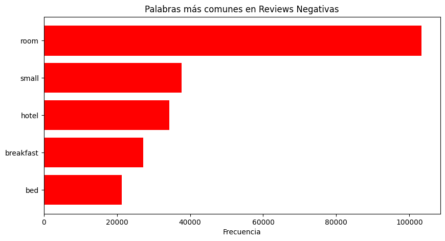

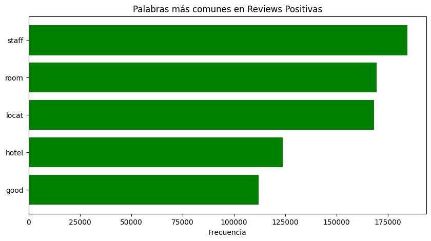

```python
# Filtra las revisiones por sentimiento
negative_reviews = reviews_df[reviews_df['Negative_Sentiment'] == 'Negativo']['Negative_Review']
positive_reviews = reviews_df[reviews_df['Positive_Sentiment'] == 'Positivo']['Positive_Review']
neutral_reviews = reviews_df[reviews_df['Negative_Sentiment'] == 'Neutral']['Negative_Review']

# Obtiene las 5 palabras más comunes en cada categoría
top_negative_words = get_top_words(negative_reviews, top_n=5)
top_positive_words = get_top_words(positive_reviews, top_n=5)
top_neutral_words = get_top_words(neutral_reviews, top_n=5)

# Prepara los datos para el histograma
words, counts = zip(*top_negative_words)
plt.figure(figsize=(10, 5))
plt.barh(words, counts, color='red')
plt.xlabel('Frecuencia')
plt.title('Palabras más comunes en Reviews Negativas')
plt.gca().invert_yaxis()  # Invertir el eje y para mostrar la palabra más común en la parte superior
plt.show()

words, counts = zip(*top_positive_words)
plt.figure(figsize=(10, 5))
plt.barh(words, counts, color='green')
plt.xlabel('Frecuencia')
plt.title('Palabras más comunes en Reviews Positivas')
plt.gca().invert_yaxis()  # Invertir el eje y para mostrar la palabra más común en la parte superior
plt.show()
```

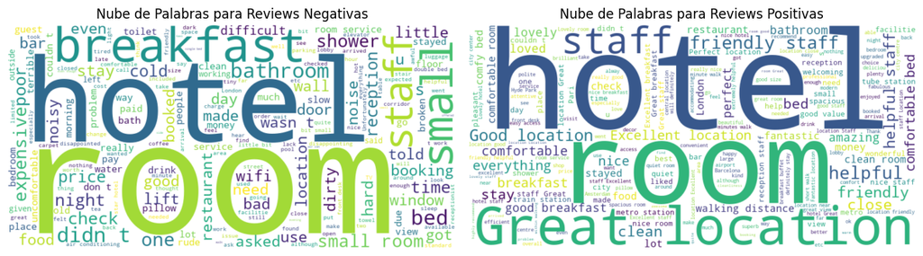

```python
# Filtrar las revisiones por sentimiento
negative_reviews = reviews_df[reviews_df['Negative_Sentiment'] == 'Negativo']['Negative_Review']
positive_reviews = reviews_df[reviews_df['Positive_Sentiment'] == 'Positivo']['Positive_Review']

# Combinar todas las revisiones en un solo texto para cada categoría
negative_text = ' '.join(negative_reviews)
positive_text = ' '.join(positive_reviews)

# Crear nubes de palabras para las revisiones negativas y positivas
wordcloud_negative = WordCloud(width=800, height=400, background_color='white').generate(negative_text)
wordcloud_positive = WordCloud(width=800, height=400, background_color='white').generate(positive_text)

# Mostrar las nubes de palabras en gráficos separados
plt.figure(figsize=(12, 6))
plt.subplot(1, 2, 1)
plt.imshow(wordcloud_negative, interpolation='bilinear')
plt.title('Nube de Palabras para Reviews Negativas')
plt.axis('off')

plt.subplot(1, 2, 2)
plt.imshow(wordcloud_positive, interpolation='bilinear')
plt.title('Nube de Palabras para Reviews Positivas')
plt.axis('off')

plt.tight_layout()
plt.show()
```

```python
# Crear un mapa centrado en una ubicación inicial (puedes ajustar las coordenadas)
m = folium.Map(location=[52.3605759, 4.9159683], zoom_start=10)

# Agrupar los datos por ubicación geográfica y calcular la media de los puntajes de las revisiones
grouped_data = reviews_df.groupby(['lat', 'lng'])['Reviewer_Score'].mean().reset_index()

# Crear una matriz de ubicaciones y puntuaciones
locations = grouped_data[['lat', 'lng']].values
scores = grouped_data['Reviewer_Score'].values

# Normalizar las puntuaciones entre 0 y 1 para el gradiente de colores
normalized_scores = (scores - scores.min()) / (scores.max() - scores.min())

# Crear un heatmap con gradientes de colores
heat_map = plugins.HeatMap(list(zip(locations[:, 0], locations[:, 1], normalized_scores)),
                            min_opacity=0.2,
                            max_val=1.0,
                            radius=15,
                            blur=10,
                            gradient={0.4: 'blue', 0.6: 'lime', 1.0: 'red'})

# Agregar el heatmap al mapa
heat_map.add_to(m)

# Mostrar el mapa
m.save('heatmap.html')  # Guardar el mapa en un archivo HTML
```

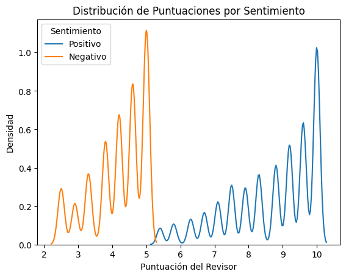

```python
# Agregar la columna 'Sentiment' al DataFrame
reviews_df['Sentiment'] = reviews_df['Reviewer_Score'].apply(determine_sentiment)

# Gráfica de densidad para revisiones positivas y negativas
for sentiment in ['Positivo', 'Negativo']:
    subset = reviews_df[reviews_df['Sentiment'] == sentiment]
    sns.distplot(subset['Reviewer_Score'], hist=False, label=sentiment)

plt.title('Distribución de Puntuaciones por Sentimiento')
plt.xlabel('Puntuación del Revisor')
plt.ylabel('Densidad')
plt.legend(title='Sentimiento')
plt.show()
```

```python
# Preprocesamiento de texto
stop_words = set(stopwords.words('english'))
stemmer = PorterStemmer()

# Combinar las columnas Positive_Review y Negative_Review en una sola columna
reviews_df['Combined_Review'] = reviews_df['Positive_Review'] + ' ' + reviews_df['Negative_Review']

# Aplicar el preprocesamiento al texto combinado6
reviews_df['Processed_Review'] = reviews_df['Combined_Review'].apply(preprocess_text)
```

```python
# Dividir el conjunto de datos en entrenamiento y prueba
X = reviews_df['Processed_Review']
y = reviews_df['Sentiment']
X_train, X_test, y_train, y_test = train_test_split(X, y, test_size=0.2, random_state=42)

# Vectorización de texto utilizando TF-IDF
tfidf_vectorizer = TfidfVectorizer(max_features=5000)
X_train_tfidf = tfidf_vectorizer.fit_transform(X_train)
X_test_tfidf = tfidf_vectorizer.transform(X_test)
```

```python
# Entrenar el modelo Random Forest Classifier
clf = RandomForestClassifier(random_state=42)
clf.fit(X_train_tfidf, y_train)

# Realizar predicciones
y_pred = clf.predict(X_test_tfidf)
```

```python
# Evaluar el modelo
accuracy = accuracy_score(y_test, y_pred)
print(f'Accuracy: {accuracy:.2f}')

print(classification_report(y_test, y_pred))

# Matriz de confusión
confusion = confusion_matrix(y_test, y_pred)
print('Confusion Matrix:')
print(confusion)
```

```
Accuracy: 0.94
              precision    recall  f1-score   support

    Negativo       0.74      0.06      0.11      6228
    Positivo       0.94      1.00      0.97     96920

    accuracy                           0.94    103148
   macro avg       0.84      0.53      0.54    103148
weighted avg       0.93      0.94      0.92    103148

Confusion Matrix:
[[  353  5875]
 [  122 96798]]
```

Accuracy (Precisión Global): El modelo tiene una precisión global del 94%. Esto significa que el 94% de las predicciones realizadas por el modelo son correctas.

Precision (Precisión): La precisión es la proporción de predicciones positivas (Positivo) que fueron verdaderamente positivas en comparación con todas las predicciones positivas. La precisión para la clase "Negativo" es del 74%, lo que significa que el 74% de las revisiones clasificadas como negativas fueron verdaderamente negativas. La precisión para la clase "Positivo" es del 94%, lo que indica que el 94% de las revisiones clasificadas como positivas fueron verdaderamente positivas.

F1-Score (Puntuación F1): El F1-score es una métrica que combina la precisión y el recall en una sola puntuación. Es especialmente útil cuando las clases están desequilibradas. El F1-score para la clase "Negativo" es bajo, solo del 11%, lo que indica un bajo rendimiento en la predicción de revisiones negativas. El F1-score para la clase "Positivo" es alto, del 97%, lo que indica un rendimiento sólido en la predicción de revisiones positivas.

Support (Soporte): Indica el número de ejemplos en cada clase. Hay 6,228 revisiones clasificadas como "Negativo" y 96,920 revisiones clasificadas como "Positivo".

Matriz de Confusión: La matriz de confusión muestra el desglose de las predicciones del modelo para cada clase. En este caso, la matriz de confusión muestra que:

El modelo clasificó correctamente 353 revisiones negativas como negativas (verdaderos negativos).

El modelo clasificó incorrectamente 5,875 revisiones negativas como positivas (falsos positivos).

El modelo clasificó incorrectamente 122 revisiones positivas como negativas (falsos negativos).

El modelo clasificó correctamente 96,798 revisiones positivas como positivas (verdaderos positivos).

En resumen, el modelo tiene un buen rendimiento en la predicción de revisiones positivas, pero un rendimiento deficiente en la predicción de revisiones negativas.